# Introducción a la Distribución Normal y el Puntaje Z en Python

**Contenidos:**

1. **El Puntaje Z**: Qué es y cómo se calcula para un solo dato.
2. **Simulación de Datos**: Cómo generar datos que sigan una distribución normal y ver la diferencia entre la teoría y una muestra.
3. **Cálculo de Probabilidades**: Usar el puntaje z para responder preguntas como "¿qué porcentaje de la gente tiene más de X simpatía?".
4. **Normalización para Comparar Grupos**: El caso de estudio de dos regiones, donde estandarizamos los datos para poder compararlos de manera justa.
5. **Aplicación Práctica**: Un ejemplo concreto que muestra por qué la normalización es útil.

```python
# Importamos las librerías que vamos a necesitar
import numpy as np
import pandas as pd
import matplotlib.pyplot as plt
from scipy.stats import norm

# Fijamos una semilla para que los resultados aleatorios sean siempre los mismos
np.random.seed(123)
```

## 1. El Puntaje Z: ¿Qué es y cómo se calcula?

El **puntaje Z** nos dice a cuántas desviaciones estándar se encuentra un valor específico de la media del grupo. Es la medida más básica de la posición relativa de un dato.

La fórmula es: $z = \frac{(x - \mu)}{\sigma}$

- $x$: El valor que queremos analizar.
- $\mu$ (mu): La media de la población.
- $\sigma$ (sigma): La desviación estándar de la población.

**Escenario**: Analizamos la simpatía hacia un candidato político en una escala de 0 a 100. Sabemos que la simpatía promedio ($\mu$) en la población es de **55 puntos**, con una desviación estándar ($\sigma$) de **12 puntos**.

**Pregunta**: ¿Qué tan común o rara es una persona con **70 puntos** de simpatía?

```python
# Parámetros de la población (teóricos)
media_poblacional = 55
desvio_poblacional = 12

# Nuestro caso observado
valor_observado = 70

# Calculamos el puntaje Z
puntaje_z = (valor_observado - media_poblacional) / desvio_poblacional

print(f"El puntaje Z para un valor de {valor_observado} es: {puntaje_z:.2f}")
print(f"Esto significa que una simpatía de {valor_observado} está a {puntaje_z:.2f} desviaciones estándar por encima de la media.")
```

```
El puntaje Z para un valor de 70 es: 1.25
Esto significa que una simpatía de 70 está a 1.25 desviaciones estándar por encima de la media.
```

## 2. De la Teoría a la Práctica: Simulación de Datos

La distribución normal teórica es una curva perfecta. En la realidad, los datos de una muestra nunca son perfectos. Vamos a ver cómo se compara una muestra simulada con la teoría.

### 2.a. Simulación con una Muestra Pequeña (N=50)

Con pocos datos, la distribución real puede ser bastante diferente de la curva teórica ideal.

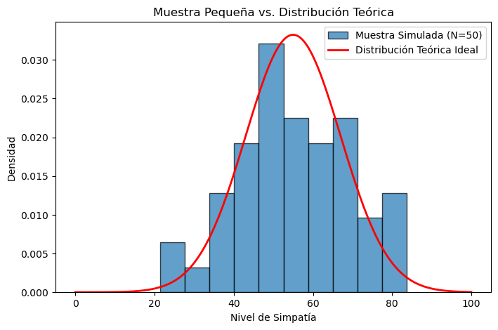

```python
# Tamaño de la muestra pequeña
N_pequeno = 50

# Generamos 50 casos que siguen una distribución Normal(μ=55, σ=12)
simulacion_pequena = np.random.normal(loc=media_poblacional, scale=desvio_poblacional, size=N_pequeno)

# Graficamos el histograma de nuestra muestra y la curva teórica
plt.figure(figsize=(8, 5))
plt.hist(simulacion_pequena, bins=10, density=True, edgecolor="black", alpha=0.7, label="Muestra Simulada (N=50)")

# Superponemos la curva de densidad de probabilidad teórica
x_grid = np.linspace(0, 100, 200)
curva_teorica = norm.pdf(x_grid, loc=media_poblacional, scale=desvio_poblacional)
plt.plot(x_grid, curva_teorica, color='red', linewidth=2, label="Distribución Teórica Ideal")

plt.title("Muestra Pequeña vs. Distribución Teórica")
plt.xlabel("Nivel de Simpatía")
plt.ylabel("Densidad")
plt.legend()
plt.show()
```

**Observación**: Fíjate cómo el histograma (los datos reales de la muestra) no se ajusta perfectamente a la curva roja (la teoría). Hay "huecos" y "picos". Esto es la **variabilidad del muestreo**.

### 2.b. Simulación con una Muestra Grande (N=10,000)

Según la **Ley de los Grandes Números**, a medida que aumenta el tamaño de la muestra, la distribución de los datos se parecerá cada vez más a la distribución teórica.

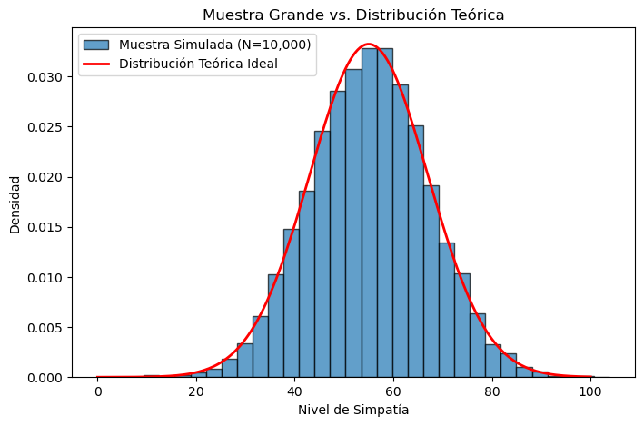

```python
# Tamaño de la muestra grande
N_grande = 10000

# Generamos 10,000 casos
simulacion_grande = np.random.normal(loc=media_poblacional, scale=desvio_poblacional, size=N_grande)

# Graficamos de nuevo
plt.figure(figsize=(8, 5))
plt.hist(simulacion_grande, bins=30, density=True, edgecolor="black", alpha=0.7, label="Muestra Simulada (N=10,000)")

# Superponemos la curva teórica
plt.plot(x_grid, curva_teorica, color='red', linewidth=2, label="Distribución Teórica Ideal")

plt.title("Muestra Grande vs. Distribución Teórica")
plt.xlabel("Nivel de Simpatía")
plt.ylabel("Densidad")
plt.legend()
plt.show()
```

**Observación**: ¡Ahora sí! Con 10,000 casos, el histograma de la muestra es un reflejo casi perfecto de la curva teórica. Esto nos da confianza para usar la teoría para calcular probabilidades.

## 3. Calculando Probabilidades y Percentiles

Ahora que confiamos en nuestro modelo, podemos usar la distribución normal teórica para responder preguntas sobre la probabilidad.

**Preguntas:** a) ¿Qué porcentaje de personas tiene una simpatía **menor a 60**? `P(X < 60)` b) ¿Qué porcentaje de personas tiene una simpatía **mayor a 70**? `P(X > 70)` c) ¿Qué nivel de simpatía es necesario para estar en el **percentil 80** (es decir, superar al 80% de la gente)?

```python
# a) Probabilidad de tener una simpatía MENOR a 60
valor_a = 60
z_a = (valor_a - media_poblacional) / desvio_poblacional
prob_a = norm.cdf(z_a)
print(f"a) La probabilidad de tener una simpatía menor a {valor_a} es: {prob_a:.4f} (o {prob_a*100:.2f}%)")

# b) Probabilidad de tener una simpatía MAYOR a 70
valor_b = 70
z_b = (valor_b - media_poblacional) / desvio_poblacional
prob_b = 1 - norm.cdf(z_b) # Usamos 1 - cdf() porque queremos el área a la DERECHA de la curva
print(f"b) La probabilidad de tener una simpatía mayor a {valor_b} es: {prob_b:.4f} (o {prob_b*100:.2f}%)")

# c) Calcular el valor que corresponde al percentil 80
percentil_80 = norm.ppf(0.80, loc=media_poblacional, scale=desvio_poblacional)
print(f"c) Para estar en el percentil 80, se necesita un nivel de simpatía de: {percentil_80:.2f}")
```

```
a) La probabilidad de tener una simpatía menor a 60 es: 0.6615 (o 66.15%)
b) La probabilidad de tener una simpatía mayor a 70 es: 0.1056 (o 10.56%)
c) Para estar en el percentil 80, se necesita un nivel de simpatía de: 65.10
```